# Problema 1 - AD1

Lucas Marlon

20 de maio de 2017

# Escolha das séries

Para realizar a análise dos dados escolhi as séries: *Friends*, *How I Met Your Mother* e *Modern Family*, pelo fato das três séries possuírem o mesmo gênero (comédia).

## Primeira pergunta

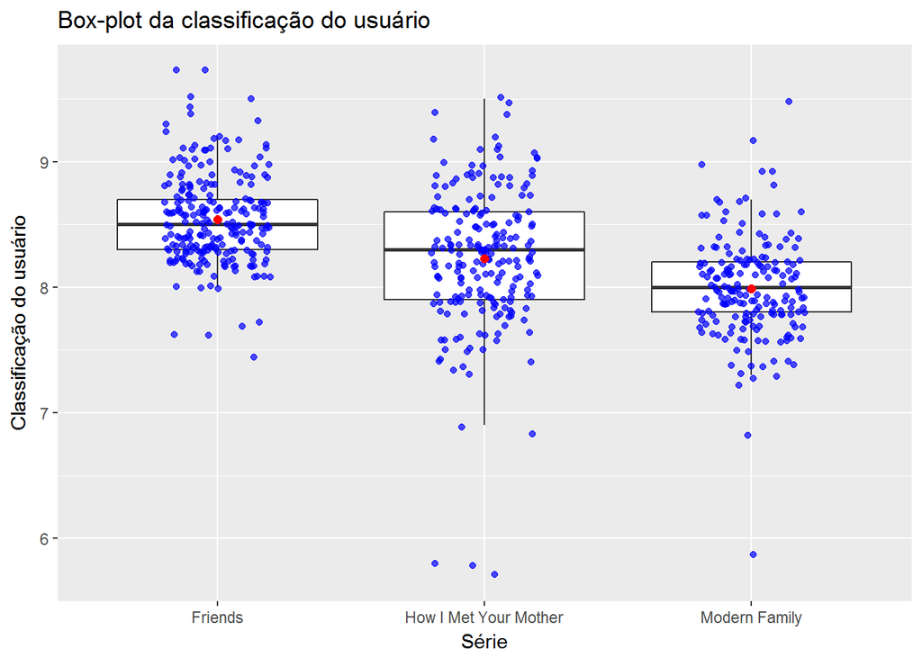

```r
medias = series %>%
  group_by(series_name) %>%
  summarise(UserRating = mean(UserRating))

  ggplot(series, mapping = aes(x = series_name,
                             y = UserRating)) +
  geom_boxplot(outlier.colour = NA) +
  geom_point(position = position_jitter(width = .2),
             alpha = .7,
             color = "blue") +
  geom_point(data = medias, colour = "red", size = 2) +
labs(title = "Box-plot da classificação do usuário", x = "Série", y = "Classificação do usuário")
```

O gráfico acima mostra a distribuição das classificações de usuários da IMDB. Podemos observar que a série *Friends* é a que mais se destaca por possuir os maiores valores de média e mediana dentre as séries avaliadas. Além disso *Friends* é a única que não apresenta valores de classificação “estranhos”, como podemos ver as séries *How I Met Your Mother* e *Modern Family* possuem valores de classifação inferiores a 6.0.

Ao observamos a dispersão dos valores no gráfico acima, e levando em consideração a classificação do usuário (UserRating), a média e a mediana como métrica de comparacão, podemos concluir que *Friends* é a série mais bem avalidada no IMDB em relação as outras duas. A mediana nos ajuda a perceber onde fica a maior concentração de avaliações das séries, diminuindo o vies de *outliers*.

A diferança entre as classificações das séries é pequena, principalmente entre as séries *Friends* e *How I Met Your Mother*, visto que a maior parte dos valores de classificação do usuário estão entre 7.5 e 9.0.

Para melhor entendimento dos valores de classificações dos usuários, vamos observar a frequência das notas para cada série, através do gráfico de barras.

### Friends

No gráfico abaixo podemos observar a frequência das classificações dos usuários para a série *Friends*. Conseguimos perceber que a maior frequência de classificações é da nota 8.5, o que nos faz esperar que a média e a mediana estejam próximas desse valor.

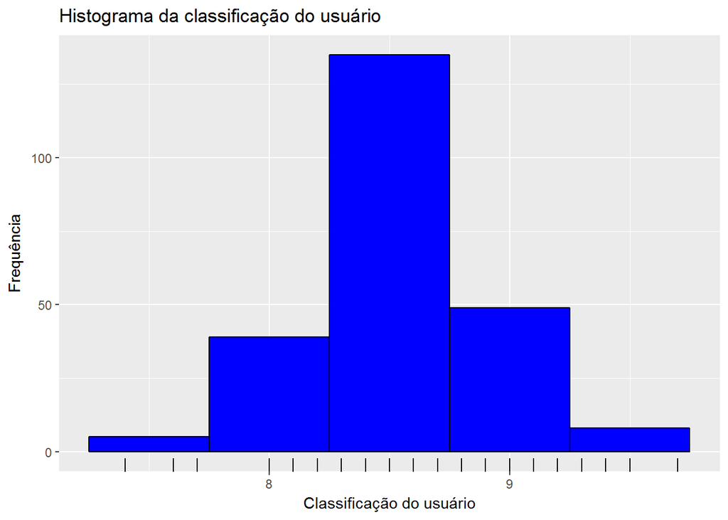

```r
series %>%
  filter(series_name == "Friends") %>%
    ggplot(aes(x = UserRating)) +
    geom_histogram(binwidth = .5, fill = "blue", color = "black") +
    geom_rug() +
  labs(title = "Histograma da classificação do usuário", x = "Classificação do usuário", y = "Frequência")
```

```r
#Média:
median((series %>%  filter(series_name == "Friends"))$UserRating)
```

```
## [1] 8.5
```

```r
#Mediana
mean((series %>%  filter(series_name == "Friends"))$UserRating)
```

```
## [1] 8.541102
```

### How I Met Your Mother

No gráfico abaixo podemos observar a frequência das classificações dos usuários para a série *How I Met Your Mother*. Conseguimos perceber que a maior frequência de classificações está entre as notas 8.0 e ~8.5, o que nos faz esperar que a média e a mediana estejam dentro deste intervalo.

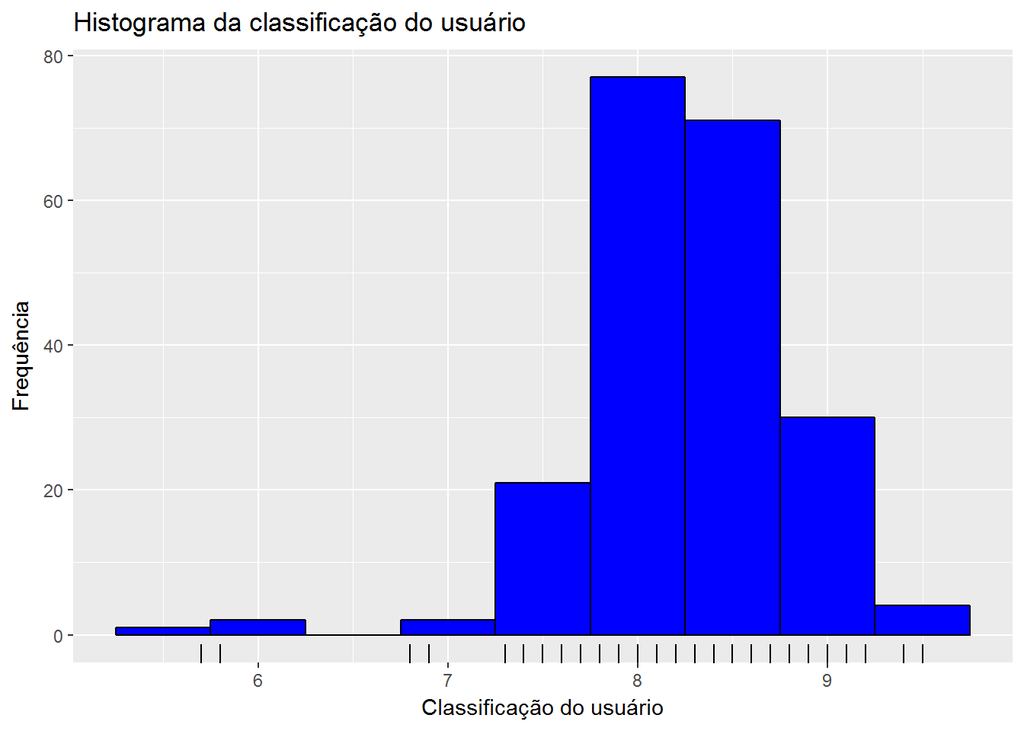

```r
series %>%
  filter(series_name == "How I Met Your Mother") %>%
    ggplot(aes(x = UserRating)) +
    geom_histogram(binwidth = .5, fill = "blue", color = "black") +
    geom_rug() +
  labs(title = "Histograma da classificação do usuário", x = "Classificação do usuário", y = "Frequência")
```

```r
#Média:
median((series %>%  filter(series_name == "How I Met Your Mother"))$UserRating)
```

```
## [1] 8.3
```

```r
#Mediana
mean((series %>%  filter(series_name == "How I Met Your Mother"))$UserRating)
```

```
## [1] 8.229327
```

### Modern Family

No gráfico abaixo podemos observar a frequência das classificações dos usuários para a série *Modern Family*. Conseguimos perceber que a maior frequência de classificações é da nota 8.0, o que nos faz esperar que a média e a mediana estejam próximas desse valor.

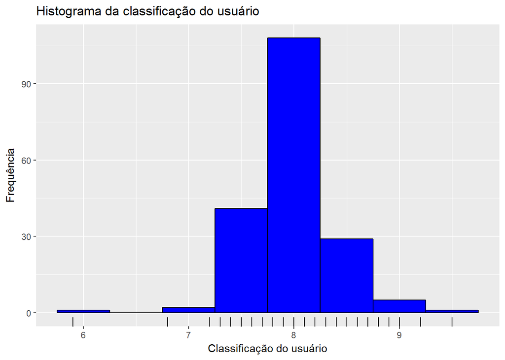

```r
series %>%
  filter(series_name == "Modern Family") %>%
    ggplot(aes(x = UserRating)) +
    geom_histogram(binwidth = .5, fill = "blue", color = "black") +
    geom_rug() +
  labs(title = "Histograma da classificação do usuário", x = "Classificação do usuário", y = "Frequência")
```

```r
#Média:
median((series %>%  filter(series_name == "Modern Family"))$UserRating)
```

```
## [1] 8
```

```r
#Mediana
mean((series %>%  filter(series_name == "Modern Family"))$UserRating)
```

```
## [1] 7.989305
```

## Segunda pergunta

Quanto a irregularidade da qualidade dos episódios segundo o IMDB, temos o seguinte:

### Friends

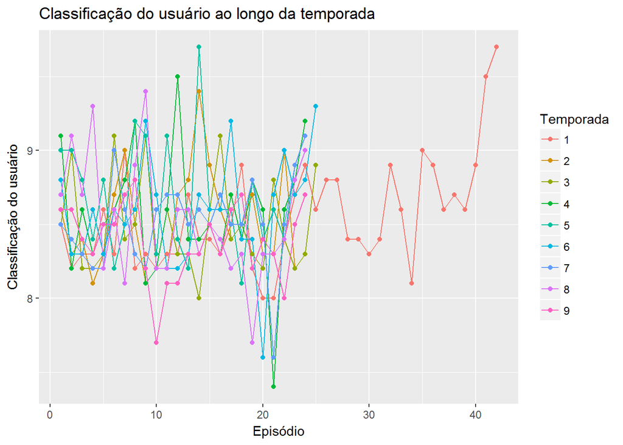

```r
series %>%  filter(series_name == "Friends") %>%
  mutate(Temporada = as.character(season)) %>%
  ggplot(aes(x = season_ep, y = UserRating, color = Temporada)) +
  geom_line() +
  geom_point() +
  labs(title = "Classificação do usuário ao longo da temporada", x = "Episódio", y = "Classificação do usuário")
```

Como podemos observar no gráfico acima, de modo geral, a série *Friends* possui grande irregularidade de qualidade de episódios na maioria de suas temporadas, apresentando alguns picos altos e outros baixos nas temporadas 4, 5 e 8, por exemplo.

**Observação:** A linha da temporada 1 aparece duas vezes devido a duplicação dos dados no arquivo series_from_imdb.csv.

### How I Met Your Mother

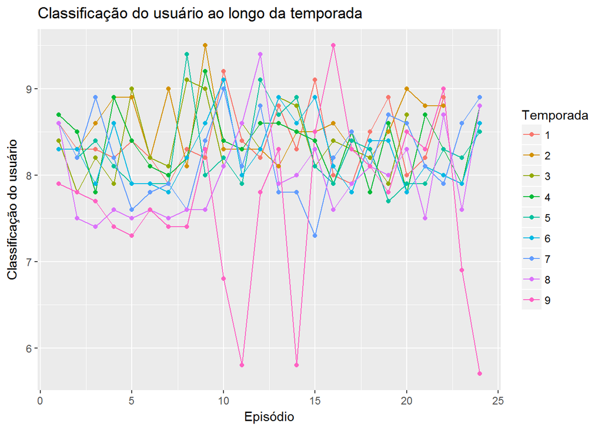

```r
series %>%  filter(series_name == "How I Met Your Mother") %>%
  mutate(Temporada = as.character(season)) %>%
  ggplot(aes(x = season_ep, y = UserRating, color = Temporada)) +
  geom_line() +
  geom_point() +
  labs(title = "Classificação do usuário ao longo da temporada", x = "Episódio", y = "Classificação do usuário")
```

Como podemos observar no gráfico acima, de modo geral a série *How I Met Your Mother* possui pequena irregularidade de qualidade de episódios na maioria de suas temporadas. Porém, o que nos chama atenção é a irregularidade de qualidade de episódios da última temporada (9), o que nos mostra que por sinal os fãs da série não ficaram nada satisfeitos com o desfecho da temporada.

### Modern Family

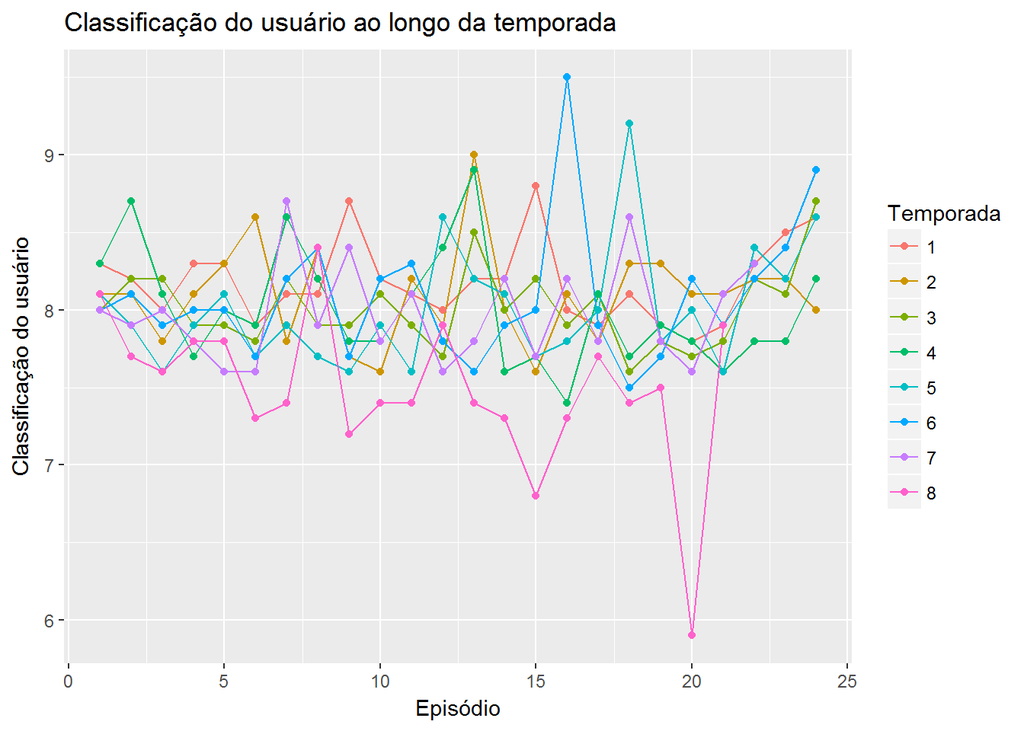

```r
series %>%  filter(series_name == "Modern Family") %>%
  mutate(Temporada = as.character(season)) %>%
  ggplot(aes(x = season_ep, y = UserRating, color = Temporada)) +
  geom_line() +
  geom_point() +
  labs(title = "Classificação do usuário ao longo da temporada", x = "Episódio", y = "Classificação do usuário")
```

Como podemos observar no gráfico acima, de modo geral a série *Modern Family* também possui pequena irregularidade de qualidade de episódios na maioria de suas temporadas, apresentando alguns picos altos nas temporadas 5 e 6, por exemplo. E na última temporada (8) nos chama bastante atenção, visto que possui grande irregularidade de qualidade dos episódios, com picos altos e baixos.

De modo geral, dentre as séries que eu escolhi a que possui mais irregularidade de qualidade dos episódios é *Friends*, pois é a que apresenta mais picos altos e baixos em mais temporadas. E a diferença de irregularidade da qualidade dos episódios entre as três séries é pequena.